# [OpenAI – ChatGPT and Codex – Coding with AI](https://fellows.fablearn.org/openai-chatgpt-and-codex-making-with-ai/)

###### “STEM Girls” Project Meetings – 2022

**An important Survey – “STEM Girls” Project**

A student from “STEM Girls”, Nicolly Figueiredo, wanted to survey exactly how many students were enrolled in these subjects. So she did exploratory research to identify the reasons that led girls at school who chose STEM electives to do so.

Two procedures were used.

The first was the survey of the number of students enrolled in each of these 7 (seven) subjects, organizing the data related to gender.

The second was the application of a questionnaire so that the girls who opted for these subjects could report their school relationship with technology, how they feel about participating in the subjects and their desire to pursue a career in the STEM area.

Thus, the first step was to identify the number of students who are enrolled in subjects focused on the STEM areas of the school.

The survey showed that among the 105 registered, 76 are boys and 29 are girls. However, it was observed that some students chose more than one subjects in these areas.

By filtering the information to identify general numbers, considering the intersections of students who enrolled in more than one subject, the following data was obtained:

– Total individual enrolled in STEM subjects: 64

– Number of girls enrolled in STEM subjects: 22

– Number of boys enrolled in STEM subjects: 42

Through this survey, a questionnaire on the Likert Scale was organized to be applied to the 22 girls who participate in these subjects. The form had the following answers: *1- I totally agree; 2-I agree; 3-I do not know; 4-I disagree; 5- I totally disagree*.

The applied form had 10 statements directly related to the participation of girls in the subjects according to the table below:

Respondents’ statements

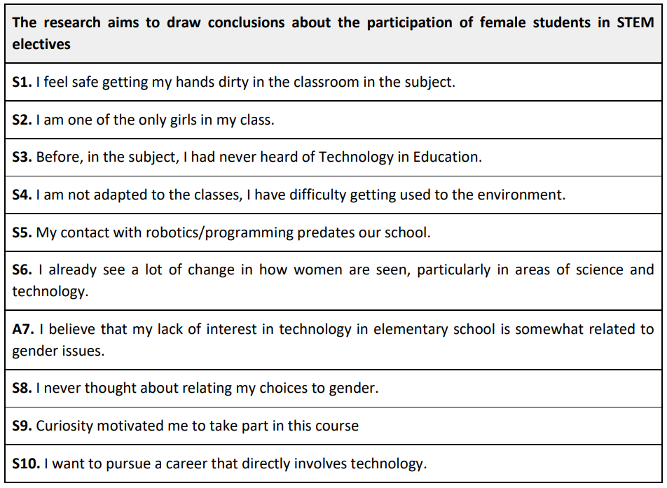

The figure presents the results obtained through the questionnaire with the statements presented in the table below.

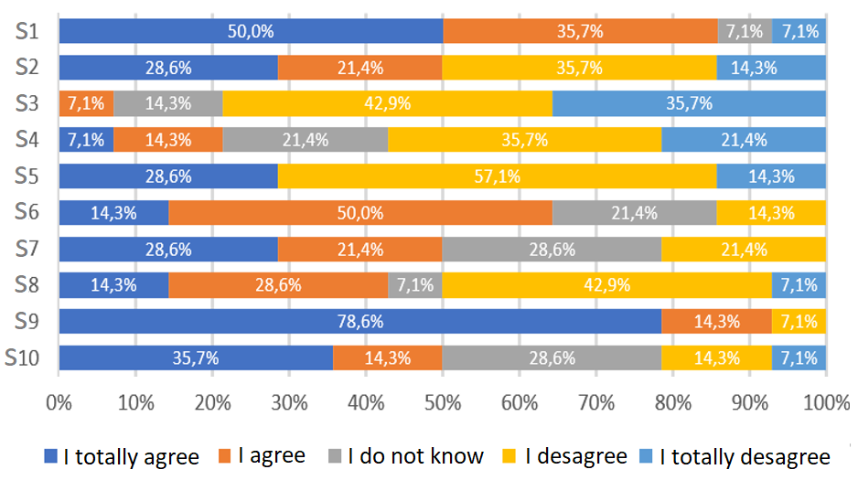

When analyzing the data from S1, we observe that the respondents feel very safe when getting their hands dirty in the classroom. In relation to S2, we see that when stating about the number of girls in the class there is a division of the answers between agreement and disagreement, 50% each. The result shows the imbalance in the number of girls in the class.

Regarding experiences with educational technologies (S3), it is worth mentioning that the term Educational Technology was not made explicit, which implies the interpretation through the respondent’s own background. Still, there is a large percentage (14.3%) who say they do not know, which can be understood as a lack of knowledge of the term.

S4 shows that there is a percentage of more than 50% that disagrees or totally disagrees with the statement about adaptation, which suggests good adaptation in the environment.

According to the data obtained in S5, it can be inferred that most of the respondents had no contact with robotics or programming in elementary school , given that our institutios is only a high school.

S7 (I believe that my lack of interest in technology in elementary school is somewhat related to gender issues) highlights that half of the respondents say they agree or totally agree with the sentence presented, the majority being “I Totally Agree”. It is notable that 28.6% of the respondents said they did not know their opinion on the sentence, which highlights the possible need for discussions that promote the theme.

Analyzing the answers obtained in S8, we observe that there is a large percentage that claims to disagree with the statement and, therefore, at some point, related their choices to gender.

In S9 there is a strong agreement, more than 50% of the respondents claim to be motivated to take part in the IF because of curiosity. From this data, it is possible to deduce that the area is a new environment for the respondents, and they are curious to learn something that is not yet known.

In statement S10, which highlights the willingness to get involved with a career directly associated with technology, it is observed that agreement stands out, with 35.7% of the answers being “I totally Agree” and 14.3% “Agree”, a fact that may present an inclination of the respondents to the career due to the contact with the area. Still, it is possible to notice that the percentage “I do not know” exceeds the disagreement as a whole.

**Conclusion:**

The first data obtained through this research was in line with what studies on gender equality in society show: the number of girls is smaller in relation to boys enrolled in STEM subjects in the initiatives available at school. Currently, female students represent approximately 34% of the total enrolled, pointing to the importance of the “STEM Girls” project for the institution.

Another important result was obtained through the questionnaire answered by the girls participating in these subjects. Their answers help to understand the motivations that led them to participate, the challenges they faced and how they see future possibilities, helping the project to propose actions to increase the number of girls participating in activities aimed at STEM areas.

Promoting initiatives in k12 education that provide students with an environment for reflection on the society in which they live is an important step so that in the future there can be more policies aimed at inclusion and equity, so that social justice can be developed.

In the future, these students will occupy roles in the job market and will be responsible for managing actions in the spaces they will occupy. Thus, awareness today is vitally important for the changes that are expected tomorrow.

# [Lets Think, Code!](https://fellows.fablearn.org/lets-think-code/)

Posted June 3, 2022 by Michael Mumbo

In January 2022, Edutab Africa had a great opportunity to facilitate a robotics session during the 12th edition of Think Young Coding Summer School in Nairobi, Kenya. This presented a chance for collaboration between two Fablearn fellows, Michael Mumbo, the co-founder of EduTab Africa, and Brenda Nyakoa from the International Rescue Committee. Our avid love for Maker education brought us together to share best practices in student-centered learning to create an engaging, interactive, and fun workshop for the boot camp participants.

[figure not shown]

The participants were largely children from Kenyan primary and a handful of secondary schools from around Nairobi. The age of the participants was between 6-16yrs. The boot camp was structured to run through 2 weekends and had sessions on Web and Game Development, Robotics, and Drones technology. Over the first weekend, we had two, three-hour introductory sessions which covered basic concepts of robotics, one in the morning and the other in the afternoon.

Since most of the learners were participating in a Robotics session for the first time, we initiated conversations with them to understand what they thought “Robotics” was all about. We used guided simple probing questions like,

> “What comes to mind when you hear the word robot?”, “What can robots do?”, “Why do we need robots?”,” what does it take to make a robot”, have you ever seen a robot?

We observed that the participants started sharing their opinions and discussing them amongst themselves. We also watched a short video clip showing how Rwanda, a country in East Africa, was using robots during the COVID-19 pandemic to reduce human contact between health care workers and patients by temperature measurements and checking the proper wearing of masks and reporting to doctors about the condition of Covid-19 patients.

We then started the robots building process where Brenda gave an overview of the different components of the programmable Lego Spike Prime kit. These components include Motors, sensors, and bricks. Through the facilitator’s guidance, the learners were able to assemble these components and built a simple driving robot. The kit uses block-based programming called the Lego Spike Prime app and so the participants were able to learn assembling easily. By the end of the session, they could program the robots to perform simple motions including moving front and back, making turns at different angles, making sounds, and using different sensors like colors and motion sensors to control the motion.

[figure not shown]

Students Assembling Robots

Reflecting on Seymour Papert’s own words in The Children’s Machine book is credited for stating that:

> *“Construction that takes place ‘in the head’ often happens especially felicitously when it is supported by the construction of a more public sort in the world”*

On the second weekend, most of the participants were familiar with the different components of the Lego kits. Instead of going through the guided process of building the robot and programming it, we gave them the freedom to explore different designs and build their robots to their liking. We gave them a simple assignment: to design a moving object that has wheels. While working in groups of about 6 students, they created and presented different creations. It was amazing to see the deep collaboration and creativity of the teams as they strategically divided themselves into smaller task forces within their groups as designers, engineers, and programmers to effectively complete the task.

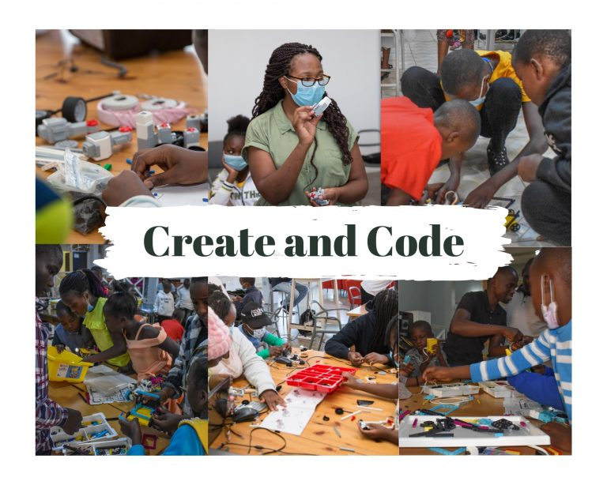

In our last session with the learners, we had a moment of reflection to collect feedback to improve future workshops for different learners. Here is what some of them had to say about their robotics experience.

> “One of my favorite moments was when I was able to build up a robot from scratch because that’s what engineers do”

> “During the robotics session, I learned how to be open-minded and appreciate other people’s decisions”

Some learners were able to showcase their robots in the closing ceremony where parents, caregivers, and other guests were invited. It was impressive how different teams were creative from different angles. For instance, one team used only color sensors to control their assembled robot to navigate the room. Another team used color sensors, motion sensors, and touch sensors to achieve similar navigation. It was encouraging to see organizations willing to support learners in their journey to creativity.

Maureen Mbaka, the Chief Administrative Secretary in the Ministry of ICT, Innovation and Youth Affairs, who attended the showcase event said,

> “We are determined to facilitate universal access to ICT infrastructure and services for the Youth through our programs.”

This collaboration opened our eyes to the possibilities that we can achieve in improving learning outcomes for students through global partnerships to share best practices and resources.